# Global Health Inequality: Regression Analysis

Ava Hu

February 2026

## Overview

Building on the descriptive analysis, this notebook explores the **predictive relationships** between global health indicators through linear regression. The primary question: *How strongly does national income predict health expenditure?*

## Setup

```r
library(tidyverse)
library(dplyr)
library(ggplot2)
library(knitr)
library(psych)
library(janitor)
library(modelr)
```

## Load Data

```r
ind <- read_csv('data/globalind.csv', col_names = TRUE)
schools <- read_csv('data/schools.csv', col_names = TRUE)
```

## Part I: Global Indicators

### Reviewing the Strongest Correlation

From the descriptive analysis, GNI and health expenditure showed the strongest correlation. Let’s examine this relationship more closely.

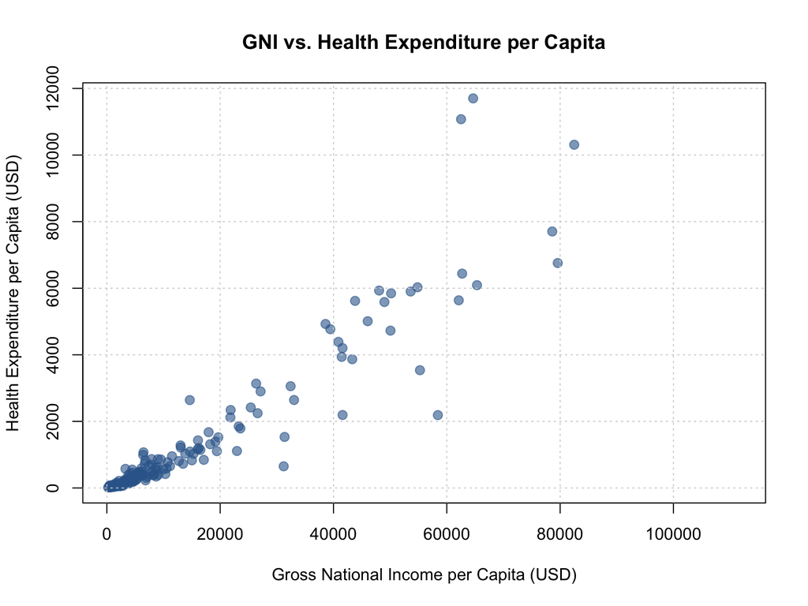

```r
plot(ind$gni, ind$healthexp,
     main = "GNI vs. Health Expenditure per Capita",
     xlab = "Gross National Income per Capita (USD)",
     ylab = "Health Expenditure per Capita (USD)",
     pch = 19,
     col = rgb(0.2, 0.4, 0.6, 0.6),
     cex = 1.2)
grid()
```

### Simple Linear Regression: GNI → Health Expenditure

A linear model with `healthexp` as the dependent variable and `gni` as the independent variable:

```r
ind_mod1 <- lm(formula = healthexp ~ gni, data = ind)
summary(ind_mod1)
```

```
##
## Call:
## lm(formula = healthexp ~ gni, data = ind)
##
## Residuals:
##     Min      1Q  Median      3Q     Max
## -3855.4  -138.5    53.5   167.3  4991.7
##
## Coefficients:
##                Estimate  Std. Error t value             Pr(>|t|)
## (Intercept) -210.326641   69.862209  -3.011              0.00298 **
## gni            0.107054    0.003063  34.953 < 0.0000000000000002 ***
## ---
## Signif. codes:  0 '***' 0.001 '**' 0.01 '*' 0.05 '.' 0.1 ' ' 1
##
## Residual standard error: 753.5 on 180 degrees of freedom
##   (40 observations deleted due to missingness)
## Multiple R-squared:  0.8716, Adjusted R-squared:  0.8709
## F-statistic:  1222 on 1 and 180 DF,  p-value: < 0.00000000000000022
```

**Interpretation:**

- **R² = 0.87** — 87% of the variation in health expenditure is explained by GNI alone.
- **p-value < 0.05** — The relationship is statistically significant.
- **GNI coefficient ≈ 0.107** — For every $1 increase in GNI per capita, health expenditure increases by approximately $0.11. In practical terms: *for every $10 increase in GNI, health spending rises by about $1.*

### Multiple Regression: Adding Unemployment

Does unemployment improve the model?

```r
ind_mod2 <- lm(formula = healthexp ~ gni + unemp, data = ind)
summary(ind_mod2)
```

```
##
## Call:
## lm(formula = healthexp ~ gni + unemp, data = ind)
##
## Residuals:
##     Min      1Q  Median      3Q     Max
## -3803.6  -144.4    54.2   197.1  4942.3
##
## Coefficients:
##                Estimate  Std. Error t value             Pr(>|t|)
## (Intercept) -316.971555  118.577630  -2.673              0.00826 **
## gni            0.107965    0.003186  33.891 < 0.0000000000000002 ***
## unemp         12.067714   10.799834   1.117              0.26543
## ---
## Signif. codes:  0 '***' 0.001 '**' 0.01 '*' 0.05 '.' 0.1 ' ' 1
##
## Residual standard error: 765.7 on 167 degrees of freedom
##   (52 observations deleted due to missingness)
## Multiple R-squared:  0.8749, Adjusted R-squared:  0.8734
## F-statistic:   584 on 2 and 167 DF,  p-value: < 0.00000000000000022
```

**Result:** Adding unemployment does **not** improve the model — the adjusted R² remains at 0.87 and unemployment’s p-value (0.265) is not significant. GNI alone is sufficient.

## Part II: California Schools

### Exploring Poverty and Academic Performance

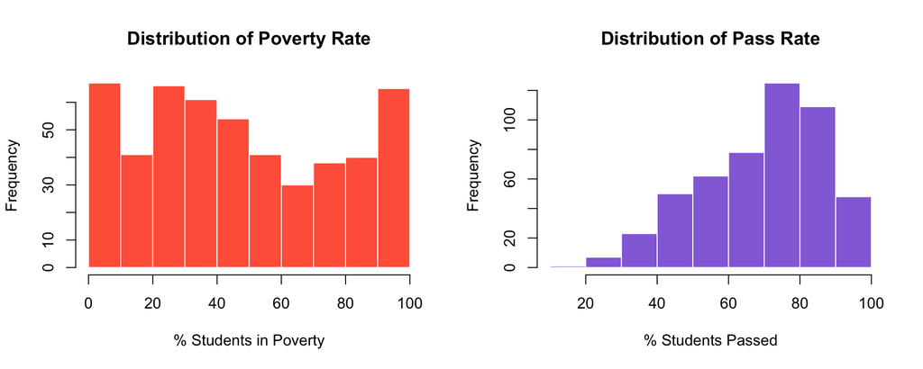

```r
par(mfrow = c(1, 2))
hist(schools$poorpct, main = "Distribution of Poverty Rate",
     xlab = "% Students in Poverty", col = "tomato", border = "white")
hist(schools$p_passed, main = "Distribution of Pass Rate",
     xlab = "% Students Passed", col = "mediumpurple", border = "white")
```

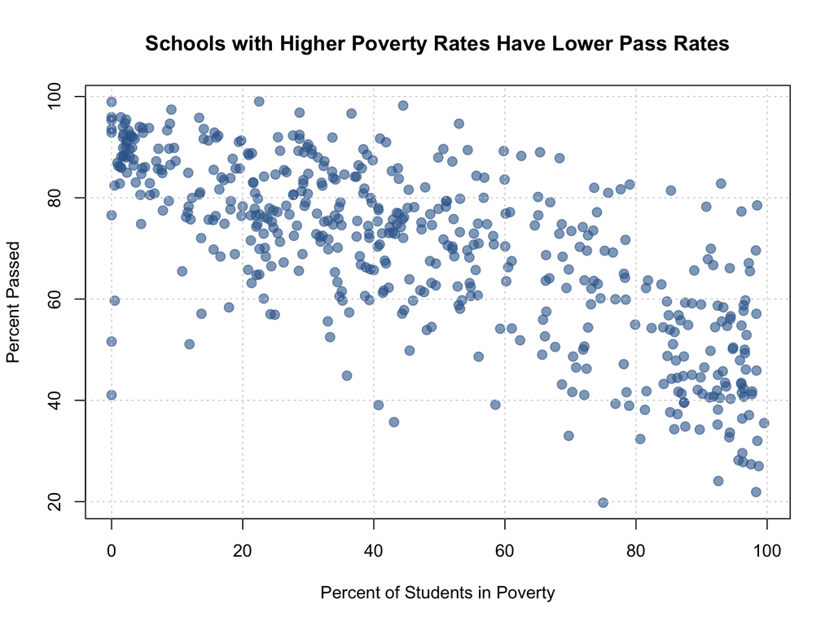

```r
plot(schools$poorpct, schools$p_passed,
     main = "Schools with Higher Poverty Rates Have Lower Pass Rates",
     xlab = "Percent of Students in Poverty",
     ylab = "Percent Passed",
     pch = 19,
     col = rgb(0.2, 0.4, 0.6, 0.6),
     cex = 1.2)
grid()
```

### Regression: Poverty → Pass Rate

```r
schools_mod1 <- lm(formula = p_passed ~ poorpct, data = schools)
summary(schools_mod1)
```

```
##
## Call:
## lm(formula = p_passed ~ poorpct, data = schools)
##
## Residuals:
##     Min      1Q  Median      3Q     Max
## -47.908  -7.152   0.898   7.443  31.933
##
## Coefficients:
##             Estimate Std. Error t value            Pr(>|t|)
## (Intercept) 88.96757    0.97996   90.79 <0.0000000000000002 ***
## poorpct     -0.40982    0.01747  -23.46 <0.0000000000000002 ***
## ---
## Signif. codes:  0 '***' 0.001 '**' 0.01 '*' 0.05 '.' 0.1 ' ' 1
##
## Residual standard error: 11.86 on 501 degrees of freedom
## Multiple R-squared:  0.5235, Adjusted R-squared:  0.5226
## F-statistic: 550.5 on 1 and 501 DF,  p-value: < 0.00000000000000022
```

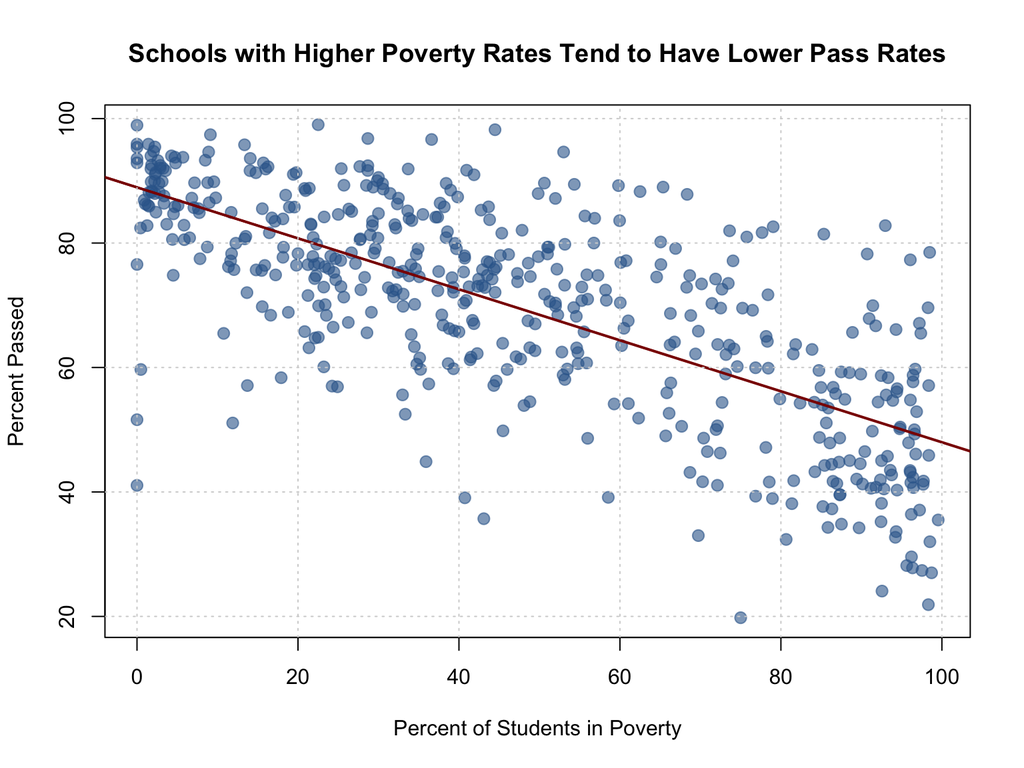

```r
plot(
  schools$poorpct,
  schools$p_passed,
  main = "Schools with Higher Poverty Rates Tend to Have Lower Pass Rates",
  xlab = "Percent of Students in Poverty",
  ylab = "Percent Passed",
  pch = 19,
  col = rgb(0.2, 0.4, 0.6, 0.6),
  cex = 1.2
)
abline(schools_mod1, col = "darkred", lwd = 2)
grid()
```

### Multiple Regression: Poverty + Minority Percentage

```r
schools_mod2 <- lm(formula = p_passed ~ poorpct + p_minority, data = schools)
summary(schools_mod2)
```

```
##
## Call:
## lm(formula = p_passed ~ poorpct + p_minority, data = schools)
##
## Residuals:
##     Min      1Q  Median      3Q     Max
## -41.921  -7.355   0.894   7.450  32.994
##
## Coefficients:
##             Estimate Std. Error t value             Pr(>|t|)
## (Intercept) 89.59312    0.98805  90.676 < 0.0000000000000002 ***
## poorpct     -0.31957    0.03207  -9.966 < 0.0000000000000002 ***
## p_minority  -0.10132    0.03031  -3.342             0.000893 ***
## ---
## Signif. codes:  0 '***' 0.001 '**' 0.01 '*' 0.05 '.' 0.1 ' ' 1
##
## Residual standard error: 11.74 on 500 degrees of freedom
## Multiple R-squared:  0.5339, Adjusted R-squared:  0.5321
## F-statistic: 286.4 on 2 and 500 DF,  p-value: < 0.00000000000000022
```

### Residual Analysis

Adding predicted values and residuals to identify outlier schools that perform significantly above or below expectations given their poverty levels:

```r
schools_pr <- schools %>%
  add_predictions(schools_mod1) %>%
  add_residuals(schools_mod1)

# Schools performing significantly ABOVE expectations (positive residuals)
outliers_positive <- schools_pr %>%
  filter(resid > 2 * sd(resid, na.rm = TRUE)) %>%
  arrange(desc(resid))

# Schools performing significantly BELOW expectations (negative residuals)
outliers_negative <- schools_pr %>%
  filter(resid < -2 * sd(resid, na.rm = TRUE)) %>%
  arrange(resid)
```

**Schools outperforming expectations** (pass rate much higher than predicted by poverty level):

```r
kable(outliers_positive %>% select(Name, poorpct, p_passed, pred, resid),
      col.names = c("School", "Poverty %", "Pass Rate", "Predicted", "Residual"),
      digits = 1,
      caption = "Schools with large positive residuals")
```

Schools with large positive residuals

| School | Poverty % | Pass Rate | Predicted | Residual |
| --- | --- | --- | --- | --- |
| PHYLLIS WHEATLEY EL | 93.0 | 82.8 | 50.9 | 31.9 |
| JULIA C FRAZIER EL | 98.5 | 78.5 | 48.6 | 29.9 |
| FANNIE C HARRIS EL | 96.1 | 77.3 | 49.6 | 27.7 |
| ROACH EL | 44.5 | 98.2 | 70.7 | 27.5 |
| ALTA MESA EL | 85.3 | 81.4 | 54.0 | 27.4 |
| MILAM EL | 53.0 | 94.6 | 67.2 | 27.4 |
| AUSTIN EL | 68.3 | 87.8 | 61.0 | 26.9 |
| CALDWELL EL | 65.4 | 89.0 | 62.2 | 26.8 |
| STEPHEN C FOSTER EL | 90.7 | 78.2 | 51.8 | 26.5 |
| SAM HOUSTON EL | 79.0 | 82.6 | 56.6 | 26.0 |
| MONTGOMERY EL | 62.5 | 88.3 | 63.4 | 24.9 |
| CENTERVILLE EL | 59.8 | 89.2 | 64.5 | 24.8 |
| GOLDEN RULE EL | 77.7 | 81.7 | 57.1 | 24.5 |

**Schools underperforming expectations** (pass rate much lower than predicted):

```r
kable(outliers_negative %>% select(Name, poorpct, p_passed, pred, resid),
      col.names = c("School", "Poverty %", "Pass Rate", "Predicted", "Residual"),
      digits = 1,
      caption = "Schools with large negative residuals")
```

Schools with large negative residuals

| School | Poverty % | Pass Rate | Predicted | Residual |
| --- | --- | --- | --- | --- |
| PLEASANT RUN EL | 0.0 | 41.1 | 89.0 | -47.9 |
| WILMER EL | 75.0 | 19.8 | 58.2 | -38.4 |
| MILLBROOK EL | 0.0 | 51.6 | 89.0 | -37.4 |
| KEMP INT | 43.1 | 35.7 | 71.3 | -35.6 |
| ADELLE TURNER EL | 40.7 | 39.1 | 72.3 | -33.2 |
| THE ACT ACAD AT J L GREER | 11.9 | 51.1 | 84.1 | -33.0 |
| T E BAXTER EL | 35.9 | 44.9 | 74.3 | -29.4 |
| ROLLING HILLS EL | 0.5 | 59.7 | 88.8 | -29.1 |
| JEFFERSON EL | 69.7 | 33.0 | 60.4 | -27.4 |
| JAMES S HOGG EL | 92.6 | 24.1 | 51.0 | -27.0 |
| ORAN M ROBERTS EL | 98.3 | 21.9 | 48.7 | -26.8 |
| LANCASTER INT | 13.7 | 57.1 | 83.3 | -26.2 |
| FINCH EL | 58.5 | 39.1 | 65.0 | -25.8 |

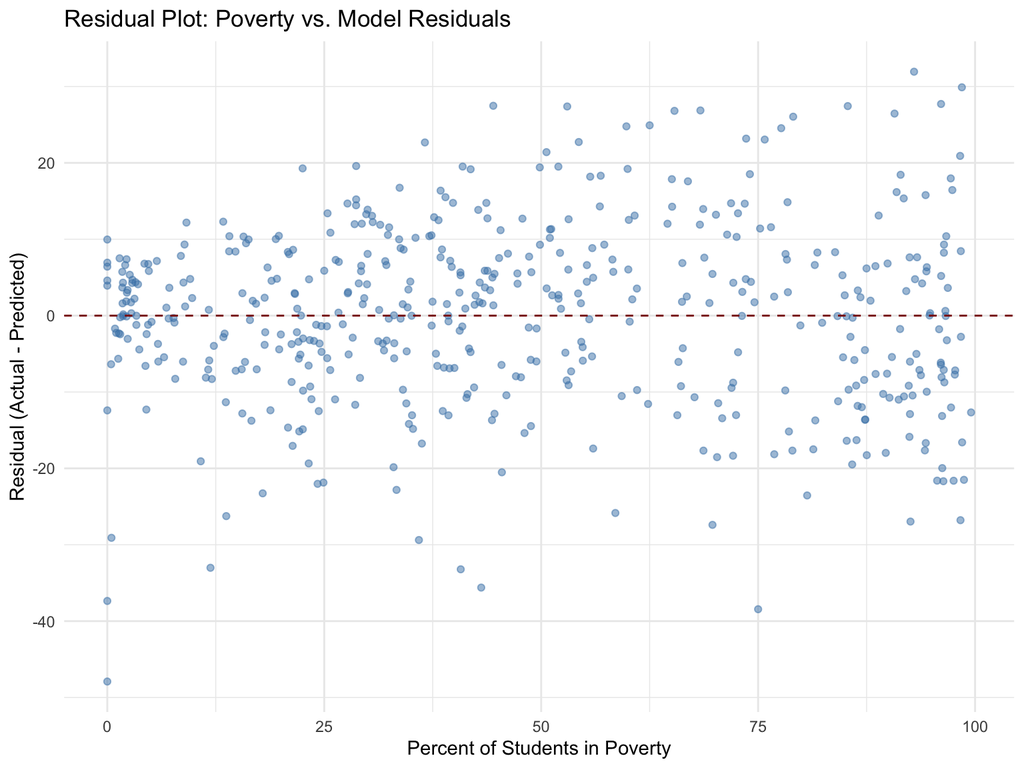

```r
ggplot(schools_pr, aes(x = poorpct, y = resid)) +
  geom_point(alpha = 0.5, color = "steelblue") +
  geom_hline(yintercept = 0, linetype = "dashed", color = "darkred") +
  labs(title = "Residual Plot: Poverty vs. Model Residuals",
       x = "Percent of Students in Poverty",
       y = "Residual (Actual - Predicted)") +
  theme_minimal()
```

*Data sources: WHO Global Health Observatory, California Schools Dataset*